# Hockey Graphs Tutorial: An Introduction to R with Hockey Data

Mobin Anandwala

July 21, 2020

# Introduction

This is a tutorial using R analyzing hockey data. The dataset was created using four game ids (unique numbers that are specific to each NHL game). The tutorial is found [here](https://hockey-graphs.com/2019/12/11/an-introduction-to-r-with-hockey-data/). The dataset was scraped on July 21st 2020 and saved into a csv file using a separate script called `game_scraper.R` which was created using the github associated with the tutorial

# Loading libraries and data

```r
library(tidyverse)

PHI_tutorial_data <- read_csv("PHI_tutorial_data.csv")
```

# Data Analysis

Let’s look at the total goals scored through out these four games. Goals may be scored at even strength (5 vs 5) power play (5 vs 4 or 4 vs 5)

## Goals

```r
goals <- PHI_tutorial_data %>% filter(event_type == "GOAL")
```

### 5 on 5 goals

```r
goals_5v5 <- PHI_tutorial_data %>% filter(event_type == "GOAL" & game_strength_state == "5v5")
```

### Power play goals (5v4 or 4v5)

```r
goals_special_teams <- PHI_tutorial_data %>% filter(event_type == "GOAL" & (game_strength_state == "5v4" | game_strength_state == "4v5"))
```

### All goals (5v5 and powerplay)

```r
goals_5v5_ST <- PHI_tutorial_data %>% filter(event_type == "GOAL" & game_strength_state %in% c("5v5", "5v4", "4v5"))
```

# Using Data to Answer questions

We want to know which player scored which goal in these four games so we don’t need all the data in the `goals` dataframe we only need the following:

- game_id
- game_date
- event_type
- event_detail (describes the type of shot used to score)
- event_team
- event_player_1 (the player scoring the goal)

```r
goals_small <- goals %>% select(game_id, game_date, event_type, event_detail, event_team, event_player_1)
```

Cleaning up the `goals` dataframe and removing event_description

```r
goals_drop <- goals %>% select(-c(event_description))

# Reorder the goals dataframe using select to have the score at the beginning
goals <- goals %>% select(home_score, away_score, everything())
```

```r
goal_variable <- PHI_tutorial_data %>% mutate(goal = ifelse(event_type == "GOAL", 1, 0))
```

Verifying that the column was added

```r
sum(goal_variable$goal)
```

```
[1] 21
```

Checking the count using the `count` function to see if the condition worked (using the event_type column)

```r
count(goal_variable, event_type)
```

| event_type | n |
| --- | --- |
| ANTHEM | 4 |
| BLOCK | 118 |
| CHANGE | 1300 |
| DELPEN | 4 |
| FAC | 237 |
| GEND | 4 |
| GIVE | 101 |
| GOAL | 21 |
| HIT | 134 |
| MISS | 71 |

[output cut: 9 more lines]

## Goals by game

```r
goals_by_game <- goal_variable %>% group_by(game_id) %>% summarise(total_goals = sum(goal))
```

We want to add the team to each game

```r
goals_by_game_team <- goal_variable %>% group_by(game_id, event_team) %>% summarise(goals = sum(goal))
goals_by_game_team
```

| game_id | event_team | goals |
| --- | --- | --- |
| 2019020336 | CAR | 3 |
| 2019020336 | PHI | 5 |
| 2019020336 | NA | 0 |
| 2019020349 | CGY | 3 |
| 2019020349 | PHI | 2 |
| 2019020349 | NA | 0 |
| 2019020367 | PHI | 2 |
| 2019020367 | VAN | 1 |
| 2019020367 | NA | 0 |
| 2019020384 | CBJ | 2 |

[output cut: 2 more lines]

We have NA values in this dataframe which doesn’t help us so let’s remove them

```r
goals_by_game_team <- goal_variable %>% filter(!is.na(event_team)) %>% group_by(game_id, event_team) %>% summarise(goals = sum(goal))
goals_by_game_team
```

| game_id | event_team | goals |
| --- | --- | --- |
| 2019020336 | CAR | 3 |
| 2019020336 | PHI | 5 |
| 2019020349 | CGY | 3 |
| 2019020349 | PHI | 2 |
| 2019020367 | PHI | 2 |
| 2019020367 | VAN | 1 |
| 2019020384 | CBJ | 2 |
| 2019020384 | PHI | 3 |

```r
goals_by_game_team <- goals_by_game_team %>% arrange(desc(goals))
goals_by_game_team
```

| game_id | event_team | goals |
| --- | --- | --- |
| 2019020336 | PHI | 5 |
| 2019020336 | CAR | 3 |
| 2019020349 | CGY | 3 |
| 2019020384 | PHI | 3 |
| 2019020349 | PHI | 2 |
| 2019020367 | PHI | 2 |
| 2019020384 | CBJ | 2 |
| 2019020367 | VAN | 1 |

# Graphs

We will now graph the amount spent in each zone

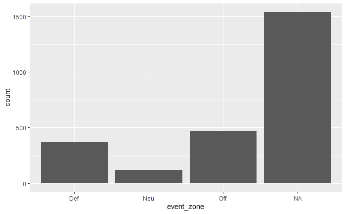

```r
ggplot(data = PHI_tutorial_data) +
  geom_bar(aes(x = event_zone))
```

Adding fills by event_zone

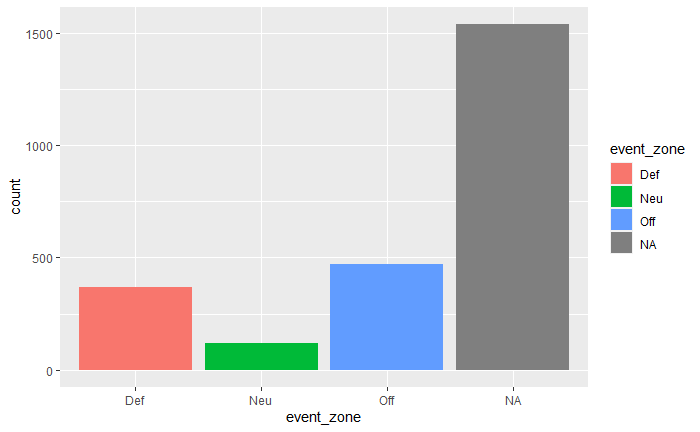

```r
ggplot(data = PHI_tutorial_data) +
  geom_bar(aes(x = event_zone, fill = event_zone))
```

Tweaking the graph

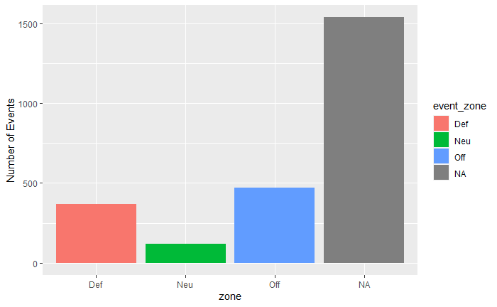

```r
ggplot(data = PHI_tutorial_data) +
  geom_bar(aes(x = event_zone, fill = event_zone)) +
  labs(y = "Number of Events") +
  labs(x = "zone")
```

Let’s filter this graph so that we are only focused on where the players are for each of these four games

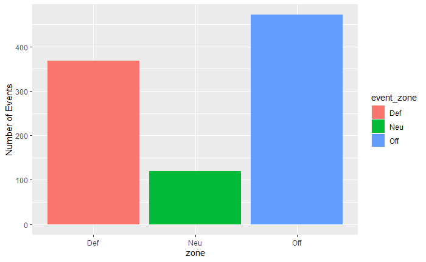

```r
zone_time <- PHI_tutorial_data %>% filter(!is.na(event_zone))
ggplot(data = zone_time) +
  geom_bar(aes(x = event_zone, fill = event_zone)) +
  labs(y = "Number of Events") +
  labs(x = "zone")
```

Also lets see how the teams did during these four games

```r
team_game_goals <- goals_by_game_team %>% group_by(event_team) %>% summarise(total_team_goals = sum(goals))
```

[output not shown]

```r
team_game_goals
```

| event_team | total_team_goals |
| --- | --- |
| CAR | 3 |
| CBJ | 2 |
| CGY | 3 |
| PHI | 12 |
| VAN | 1 |

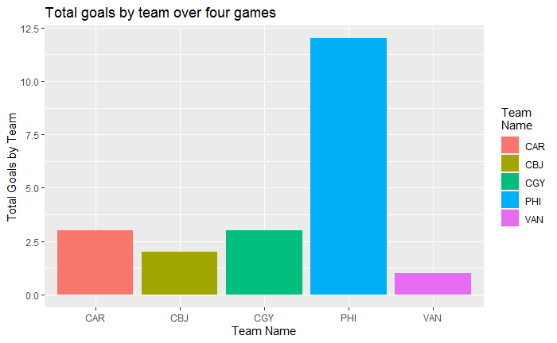

```r
ggplot(data = team_game_goals) +
  geom_col(aes(x = event_team, y = total_team_goals, fill = event_team)) +
  labs(x = "Team Name") +
  labs(y = "Total Goals by Team") +
  labs(title = "Total goals by team over four games") +
  scale_fill_discrete(name = "Team\nName")
```

The flyers scored the most goals over four games